# R tutorial China: First steps

Julia Chacón

17/2/2020

# TRANSPLANT EXPERIMENT GONGGA MOUNTAIN (CHINA)

This is an R tutorial for working with the Transplant Experiment data in Gongga Mountain, China. The purpose of the tutorial is to be able to download the data, read them and understand their structure prior to “play” with them.

## STUDY AND SITE INFORMATION

The transplant study is located in the Gongga Mountains in Sichuan Province, south-west China. The study contains four sites spanning from 3000 to 4130 m a.s.l. along an elevational gradient. The vegetation ranges from coniferous-broadleaved forest to alpine meadows.

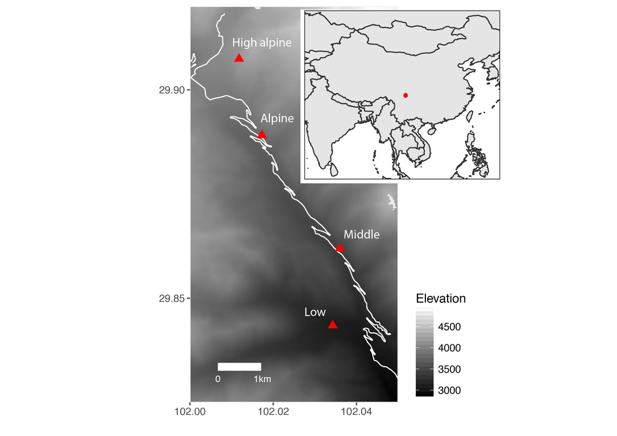

Location of the four study sites along an elevational gradient. Inset indicates the locations of the study sites in China.

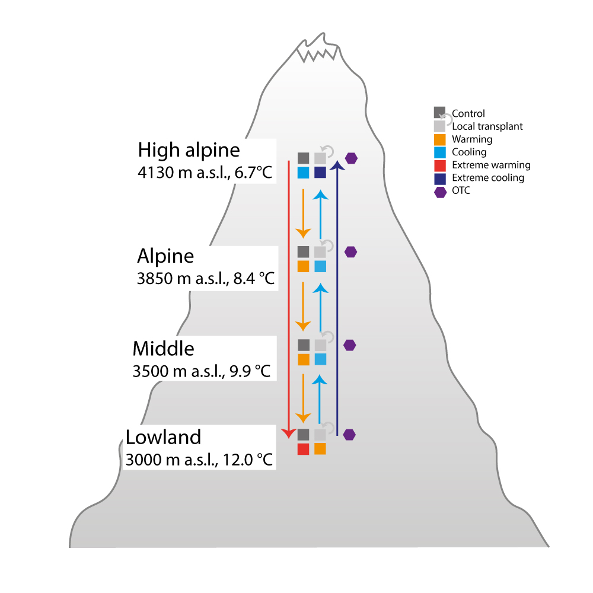

Experimental set up for the different warming treatments at each site. Shown are control, local control, OTC, and transplant and arrows indicate direction of transplant

## 1. Install the libraries

First, is important to install all the libraries needed (1), check that indeed we have all the library needed installed (2), call these libraries (3) and download the data to the correct folders.

Here are all the steps to follow. The .R files are scripts with the codes. Open the files if you want to see the instructions (highly recommended).

```r
source("install_packages.R")
```

## 2. Check out if everything is updated

Check R version and libraries

```r
source("setup.R")
```

## 3. Call the libraries

```r
library("tidyverse")
library("dataDownloader")
library("DBI")
library("vegan")
library("ggvegan")
library("patchwork")
```

## 4. Download the data

I think it is important for you to inspect this file “instructions_to_download.R”

```r
source("instructions_to_download.R")
```

## 5. Read the data

### Cover and composition data

The script to read and process the cover data is here:

```r
source("start_here.R")
```

This script is going to:

1. Read the data from the transplants (transplant.sqlite)
2. Load cover data and metadata (cover_thin)
3. Make a fat table (cover) with species names in columns and cover values in each plot
4. Make meta data (cover_meta) This are the meta data of the “cover” tibble

We can either source it or run it step by step to see what is doing (preferred option). If you want to run it step by step then open the file.

### Trait data

The traits data are located in China/traits/data, in two files: LeafTraits and ChemicalTraits. To read the csv files:

```r
traitsLeaf <- read_csv(file = "traits/data/PFTC1.2_China_2015_2016_LeafTraits.csv", col_names = TRUE)

traitsChem <- read_csv(file = "traits/data/PFTC1.2_China_2015_2016_ChemicalTraits.csv", col_names = TRUE)
```